# Mushroom Data Analysis

# Índice

1. Introducción
2. Cargar librerías
3. Cargar datos
4. Visualización y preprocesamiento  
   4.1 Imputación de valores nulos  
   4.2 Codificación de variables categóricas  
   4.3 Escalado de variables numéricas

# Introduction

# Cargar librerías

```r
library(caret)
library(tidyverse)
```

# Cargar datos

Realizamos la lectura del fichero csv, separándolo por “;” y mostramos las primeras 6 filas del fichero.

```r
mushroom <- read.csv("data.csv", sep = ";")
head(mushroom)
```

|  | class | cap.diameter | cap.shape | cap.surface | cap.color | does.bruise.or.bleed | gill.attachment | gill.spacing | gill.color | stem.height | stem.width | stem.root | stem.surface | stem.color | veil.type | veil.color | has.ring | ring.type | spore.print.color | habitat | season |
| --- | --- | --- | --- | --- | --- | --- | --- | --- | --- | --- | --- | --- | --- | --- | --- | --- | --- | --- | --- | --- | --- |
| 1 | p | 15.26 | x | g | o | f | e |  | w | 16.95 | 17.09 | s | y | w | u | w | t | g |  | d | w |
| 2 | p | 16.60 | x | g | o | f | e |  | w | 17.99 | 18.19 | s | y | w | u | w | t | g |  | d | u |
| 3 | p | 14.07 | x | g | o | f | e |  | w | 17.80 | 17.74 | s | y | w | u | w | t | g |  | d | w |
| 4 | p | 14.17 | f | h | e | f | e |  | w | 15.77 | 15.98 | s | y | w | u | w | t | p |  | d | w |
| 5 | p | 14.64 | x | h | o | f | e |  | w | 16.53 | 17.20 | s | y | w | u | w | t | p |  | d | w |
| 6 | p | 15.34 | x | g | o | f | e |  | w | 17.84 | 18.79 | s | y | w | u | w | t | p |  | d | u |

[output not shown]

```r
summary(mushroom)
```

```
##     class            cap.diameter     cap.shape         cap.surface
##  Length:61069       Min.   : 0.380   Length:61069       Length:61069
##  Class :character   1st Qu.: 3.480   Class :character   Class :character
##  Mode  :character   Median : 5.860   Mode  :character   Mode  :character
##                     Mean   : 6.734
##                     3rd Qu.: 8.540
##                     Max.   :62.340
##   cap.color         does.bruise.or.bleed gill.attachment    gill.spacing
##  Length:61069       Length:61069         Length:61069       Length:61069
##  Class :character   Class :character     Class :character   Class :character
##  Mode  :character   Mode  :character     Mode  :character   Mode  :character
##
##
##
##   gill.color         stem.height       stem.width      stem.root
##  Length:61069       Min.   : 0.000   Min.   :  0.00   Length:61069
##  Class :character   1st Qu.: 4.640   1st Qu.:  5.21   Class :character
##  Mode  :character   Median : 5.950   Median : 10.19   Mode  :character
##                     Mean   : 6.582   Mean   : 12.15
##                     3rd Qu.: 7.740   3rd Qu.: 16.57
##                     Max.   :33.920   Max.   :103.91
##  stem.surface        stem.color         veil.type          veil.color
##  Length:61069       Length:61069       Length:61069       Length:61069
##  Class :character   Class :character   Class :character   Class :character
##  Mode  :character   Mode  :character   Mode  :character   Mode  :character
##
##
##
##    has.ring          ring.type         spore.print.color    habitat
##  Length:61069       Length:61069       Length:61069       Length:61069
##  Class :character   Class :character   Class :character   Class :character
##  Mode  :character   Mode  :character   Mode  :character   Mode  :character
##
##
##
##     season
##  Length:61069
##  Class :character
##  Mode  :character
##
##
##
```

# Visualización y preprocesamiento

Sustituimos los valores vacíos por NA para poder trabajar con ellos.

```r
mushroom[mushroom == ""] <- NA
```

Comprobamos que se han sustituido los valores vacíos por NA.

```r
str(mushroom)
```

```
## 'data.frame':    61069 obs. of  21 variables:
##  $ class               : chr  "p" "p" "p" "p" ...
##  $ cap.diameter        : num  15.3 16.6 14.1 14.2 14.6 ...
##  $ cap.shape           : chr  "x" "x" "x" "f" ...
##  $ cap.surface         : chr  "g" "g" "g" "h" ...
##  $ cap.color           : chr  "o" "o" "o" "e" ...
##  $ does.bruise.or.bleed: chr  "f" "f" "f" "f" ...
##  $ gill.attachment     : chr  "e" "e" "e" "e" ...
##  $ gill.spacing        : chr  NA NA NA NA ...
##  $ gill.color          : chr  "w" "w" "w" "w" ...
##  $ stem.height         : num  16.9 18 17.8 15.8 16.5 ...
##  $ stem.width          : num  17.1 18.2 17.7 16 17.2 ...
##  $ stem.root           : chr  "s" "s" "s" "s" ...
##  $ stem.surface        : chr  "y" "y" "y" "y" ...
##  $ stem.color          : chr  "w" "w" "w" "w" ...
##  $ veil.type           : chr  "u" "u" "u" "u" ...
##  $ veil.color          : chr  "w" "w" "w" "w" ...
##  $ has.ring            : chr  "t" "t" "t" "t" ...
##  $ ring.type           : chr  "g" "g" "g" "p" ...
##  $ spore.print.color   : chr  NA NA NA NA ...
##  $ habitat             : chr  "d" "d" "d" "d" ...
##  $ season              : chr  "w" "u" "w" "w" ...
```

Visualizamos los valores nulos de cada variable. Se puede observar que existen 5 variables donde más del 50% de los valores son nulos. Estas variables son: stem.surface, veil.color, spore.print.color, stem.root, veil.type. Esta información nos puede ayudar a decidir si es conveniente eliminar dichas variables o no. En este caso, dichas variables serán eliminadas ya que, en caso de imputar los valores nulos, se perdería mucha información.

```r
colSums(is.na(mushroom))
```

```
##                class         cap.diameter            cap.shape
##                    0                    0                    0
##          cap.surface            cap.color does.bruise.or.bleed
##                14120                    0                    0
##      gill.attachment         gill.spacing           gill.color
##                 9884                25063                    0
##          stem.height           stem.width            stem.root
##                    0                    0                51538
##         stem.surface           stem.color            veil.type
##                38124                    0                57892
##           veil.color             has.ring            ring.type
##                53656                    0                 2471
##    spore.print.color              habitat               season
##                54715                    0                    0
```

Decidimos eliminar aquellas variables que cuenten con más del 50% de valores nulos. Para ello, obtendremos el nombre de las columnas que queremos eliminar.

```r
nacols <- colnames(mushroom)[colSums(is.na(mushroom)) > nrow(mushroom) / 2]
print(nacols)
```

```
## [1] "stem.root"         "stem.surface"      "veil.type"
## [4] "veil.color"        "spore.print.color"
```

Eliminamos las variables no deseadas.

```r
mushroom <- mushroom[, !names(mushroom) %in% nacols]
```

Comprobamos que se han eliminado las variables con más del 50% de valores nulos.

```r
print(colnames(mushroom))
```

```
##  [1] "class"                "cap.diameter"         "cap.shape"
##  [4] "cap.surface"          "cap.color"            "does.bruise.or.bleed"
##  [7] "gill.attachment"      "gill.spacing"         "gill.color"
## [10] "stem.height"          "stem.width"           "stem.color"
## [13] "has.ring"             "ring.type"            "habitat"
## [16] "season"
```

Separamos las variables numéricas de las categóricas.

```r
colsnames <- colnames(mushroom)
numerical_features <- c("cap.diameter", "stem.height", "stem.width")
categorical_features <- colsnames[!colsnames %in% numerical_features]
print(categorical_features)
```

```
##  [1] "class"                "cap.shape"            "cap.surface"
##  [4] "cap.color"            "does.bruise.or.bleed" "gill.attachment"
##  [7] "gill.spacing"         "gill.color"           "stem.color"
## [10] "has.ring"             "ring.type"            "habitat"
## [13] "season"
```

```r
print(numerical_features)
```

```
## [1] "cap.diameter" "stem.height"  "stem.width"
```

Comprobamos los valores posibles de cada variable categórica y su frecuencia.

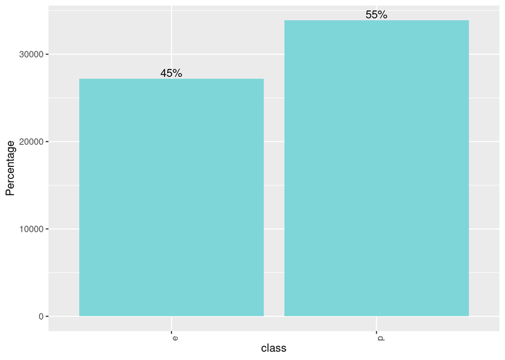

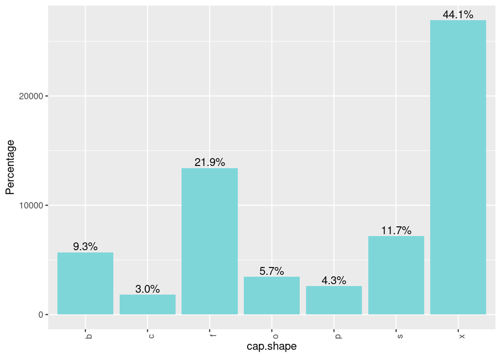

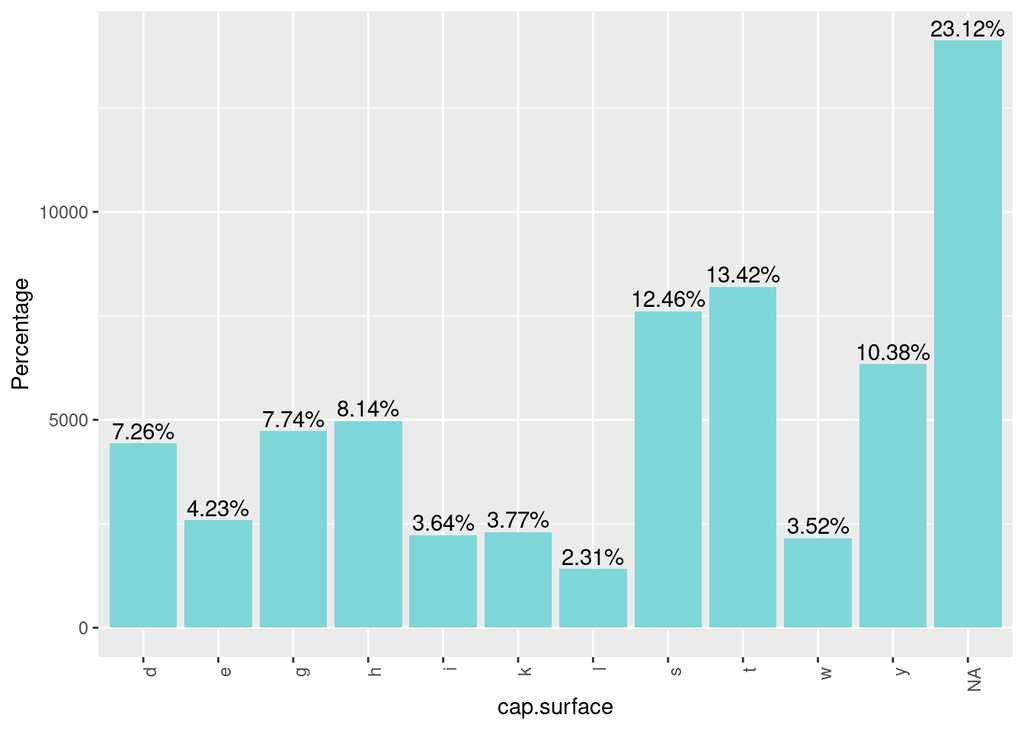

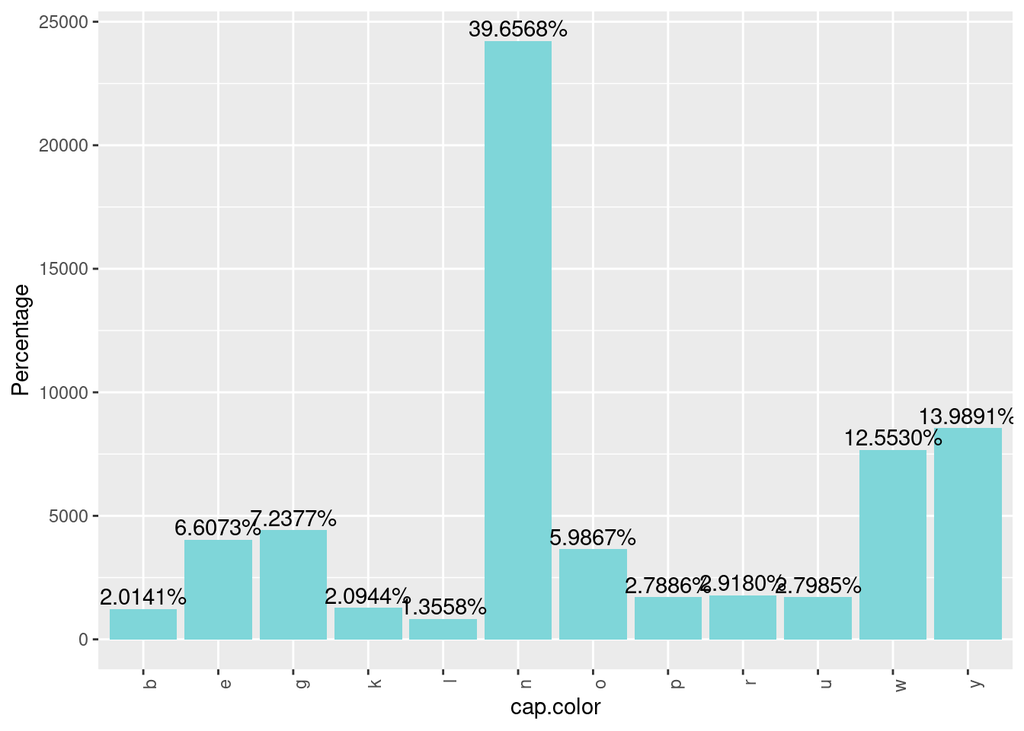

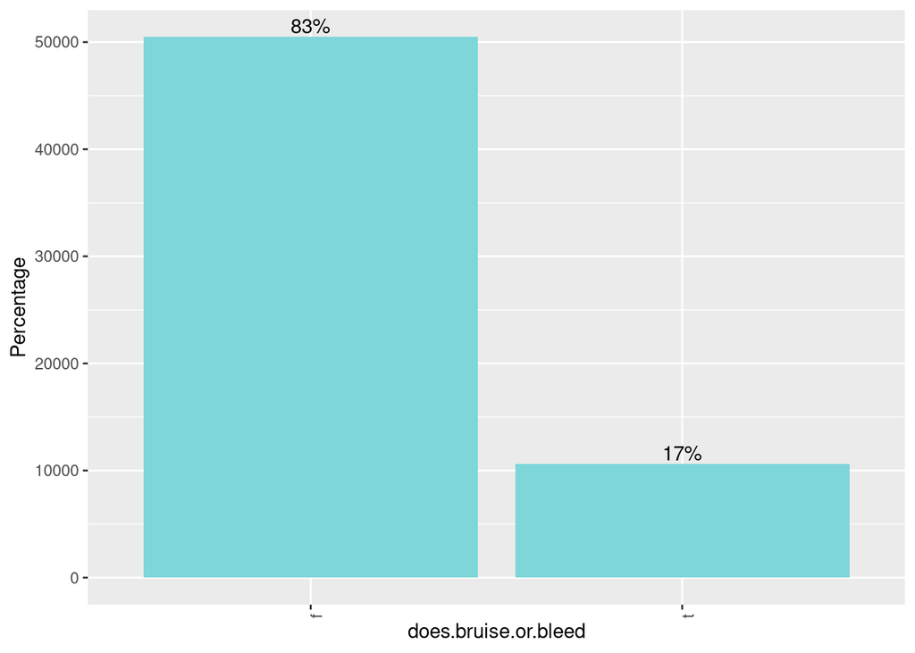

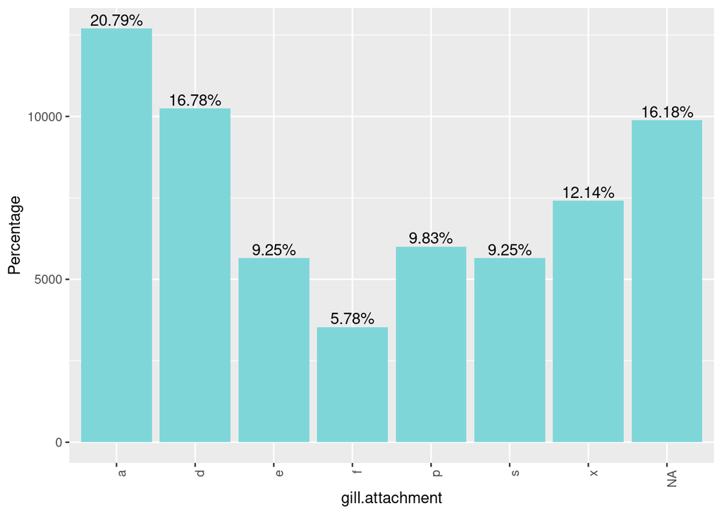

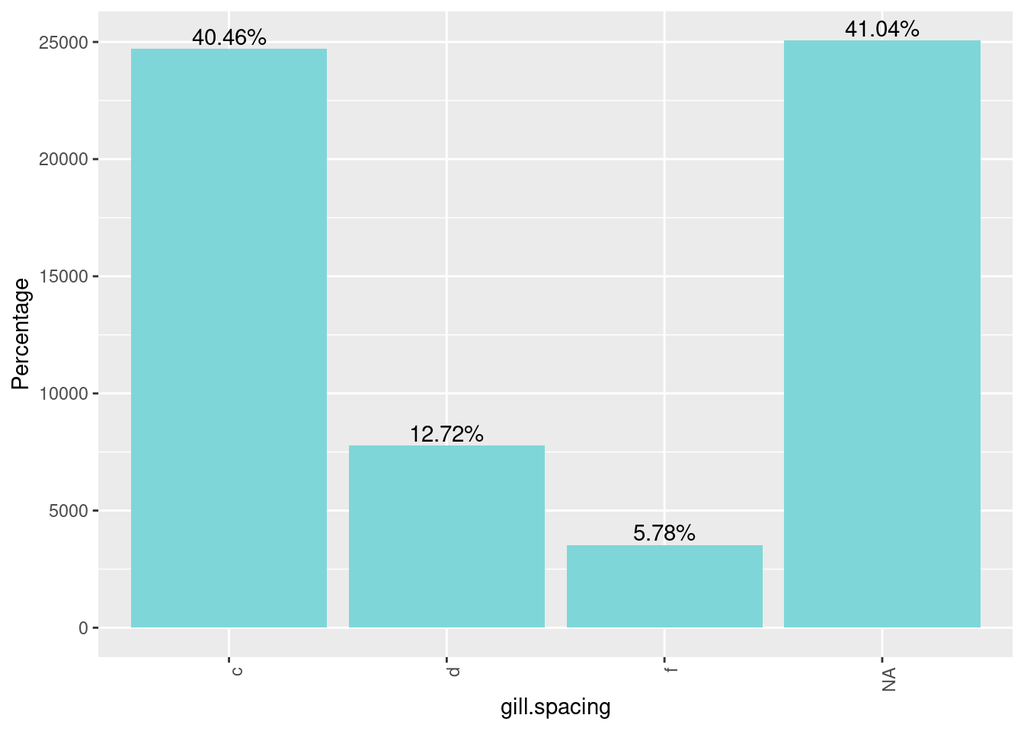

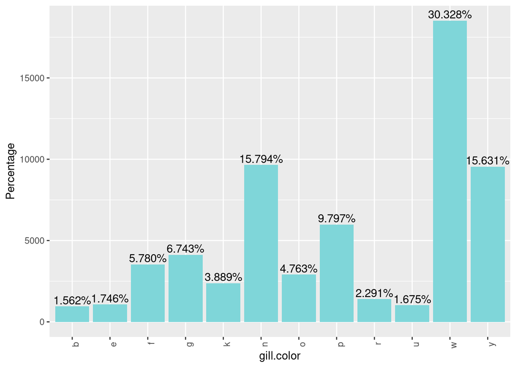

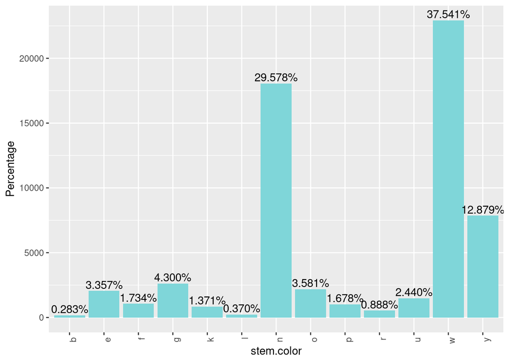

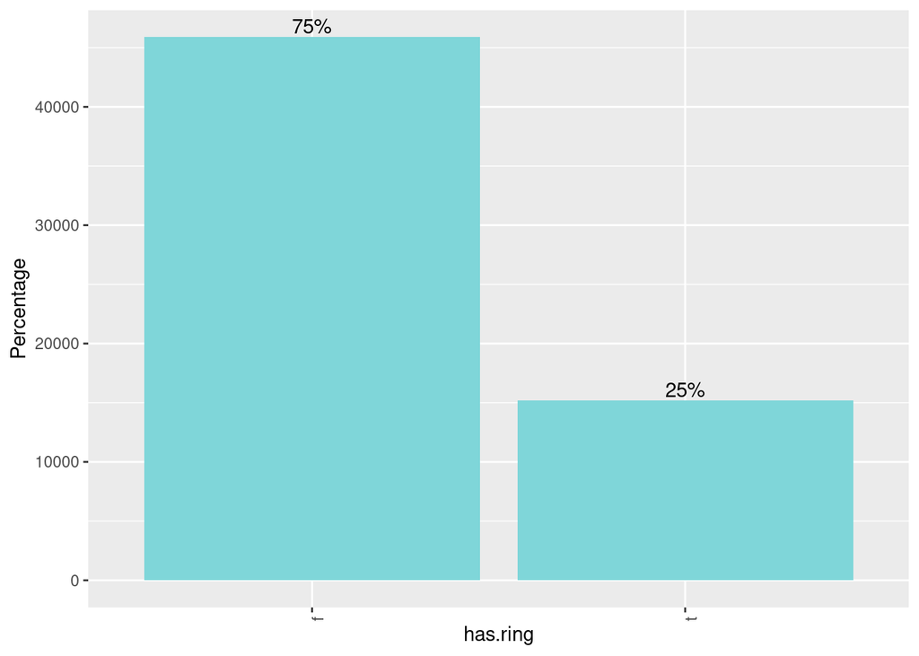

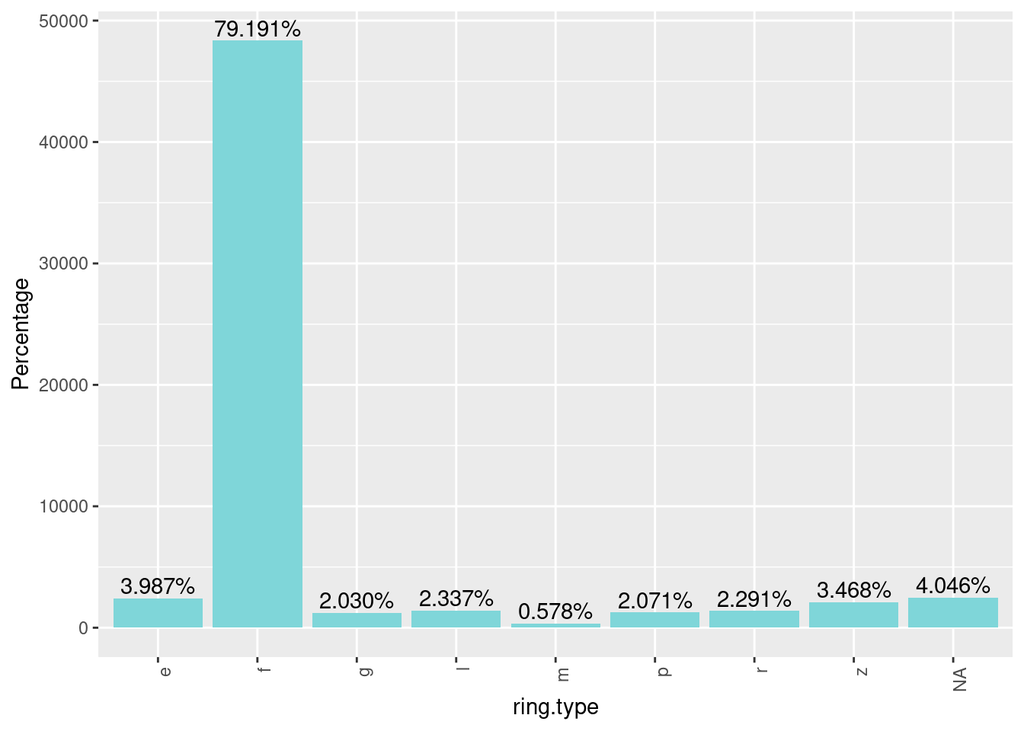

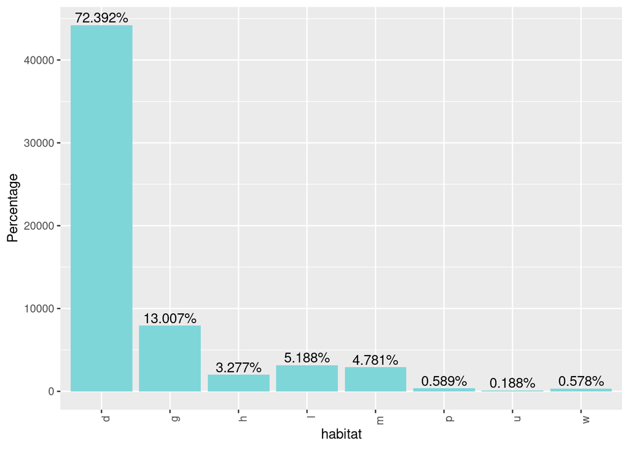

[1 more figures not shown]

```r
for (i in categorical_features) {
  print(ggplot(mushroom, aes_string(x = i)) +
    geom_bar(fill = "#7fd6d9") +
    geom_text(stat = "count", aes(label = scales::percent(..count.. / nrow(mushroom)), vjust = -0.25)) +
    labs(x = i, y = "Percentage") +
    theme(axis.text.x = element_text(angle = 90, hjust = 1))
  )
}
```

Tras visualizar los histogramas de cada variable, llegamos a las siguientes conclusiones:

- La variable dependiente “class” está balanceada, ya que la frecuencia de “e” y “p” es similar, en una proporción de 44,5% y 55,5% respectivamente. Por lo tanto, no es necesario realizar un balanceo de la variable dependiente, permitiendo aplicar la medida de evaluación “accuracy” para evaluar el modelo.
- Los valores NA de los atributos restantes serán imputados con la moda de cada variable.

A continuación, visualizaremos la distribución de las variables numéricas a través de una gráfica generada con “featurePlot”. Esta requiere que la variable objetivo sea de tipo factor, por lo que hacemos la conversión.

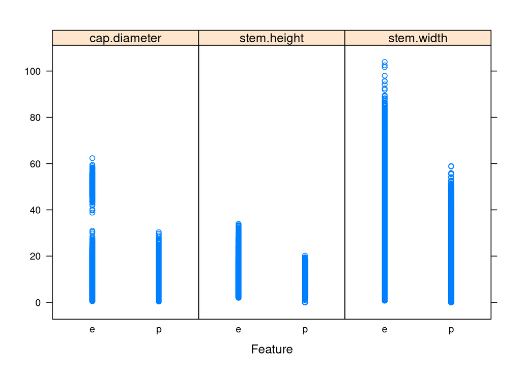

```r
mushroom$class <- as.factor(mushroom$class)
featurePlot(x = mushroom[, numerical_features], y = mushroom$class, plot = "strip")
```

Con la gráfica anterior, se puede observar que para valores altos de cap.diameter, stem.height y stem.width, la probabilidad de que la clase sea “e” es mayor que la de “p”.

Para decidir si es conveniente eliminar alguna variable, se puede utilizar la función “nearZeroVar”. Esta función devuelve un vector con los índices de las variables que tienen una varianza cercana a 0.

```r
near_zero_col <- nearZeroVar(mushroom, saveMetrics = FALSE)
colnames(mushroom)[c(near_zero_col)]
```

```
## [1] "ring.type"
```

Como conclusión, la variable “ring.type” podría ser eliminada ya que tiene una varianza cercana a 0. A continuación, visualizaremos la correlación existente con la variable dependiente “class”.

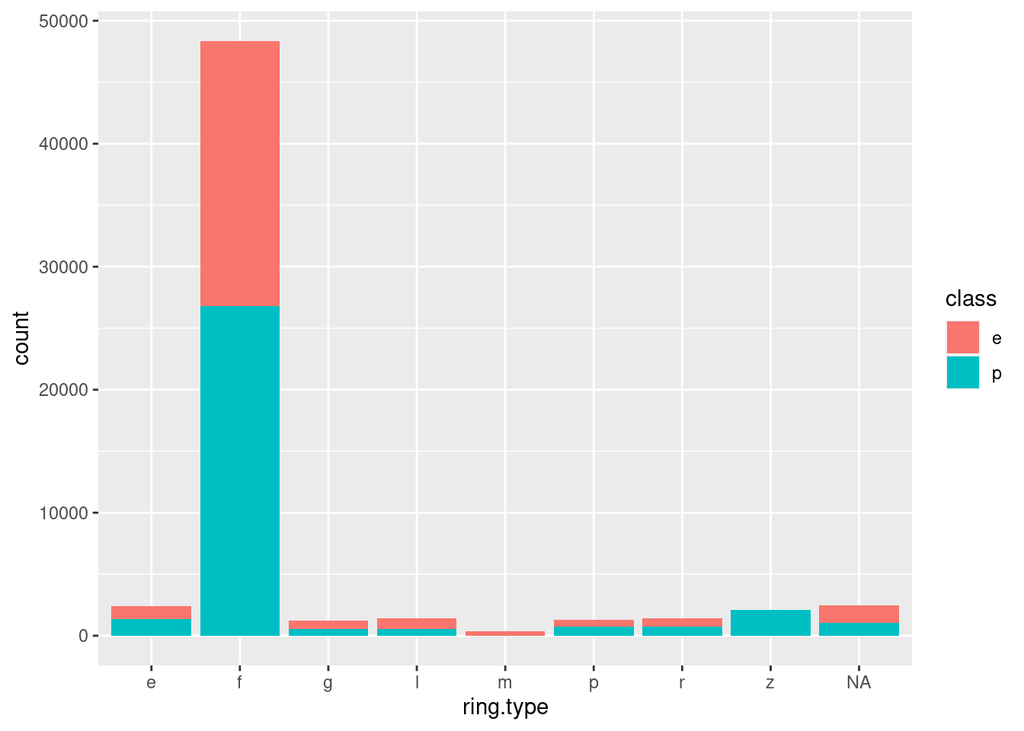

```r
print(ggplot(mushroom, aes_string(x = "ring.type")) +
  geom_bar(aes(fill = class)))
```

Tras visualizar la gráfica anterior, se puede observar que la distribución de la variable dependiente “class” es similar en casi todos los valores de “ring.type”. Sin embargo, en el caso de “ring.type” = “z” y “ring.type” = “m”, la distribución de la variable dependiente “class” es diferente. Por lo tanto, se decide no eliminar la variable “ring.type”.

## Imputación de valores nulos

Como se ha comentado anteriormente, los valores nulos de las variables categóricas se imputarán a través de la moda de cada variable. Esto es debido a que la función preProcess() de la librería caret no permite imputar valores nulos de variables categóricas.

```r
for (i in categorical_features) {
  mushroom[, i][is.na(mushroom[, i])] <- names(which.max(table(mushroom[, i])))
}
```

Podemos comprobar que ya no existen valores nulos en las variables categóricas.

```r
colSums(is.na(mushroom))
```

```
##                class         cap.diameter            cap.shape
##                    0                    0                    0
##          cap.surface            cap.color does.bruise.or.bleed
##                    0                    0                    0
##      gill.attachment         gill.spacing           gill.color
##                    0                    0                    0
##          stem.height           stem.width           stem.color
##                    0                    0                    0
##             has.ring            ring.type              habitat
##                    0                    0                    0
##               season
##                    0
```

## Codificación de variables categóricas

Para codificar las variables categóricas, se utilizará la función dummyVars() de la librería caret. Esta función devuelve un objeto de tipo “dummyVars” que contiene la información necesaria para codificar las variables categóricas. A continuación, se codificarán las variables categóricas y se eliminarán las variables originales.

```r
mushroom <- dummyVars(" ~ .", data = mushroom, fullRank = TRUE) %>% predict(mushroom)
mushroom <- as.data.frame(mushroom)
```

Visualizamos las variables categóricas codificadas y las dimensiones del dataset.

```r
dim_mushroom <- dim(mushroom)
print(dim_mushroom)
```

```
## [1] 61069    81
```

```r
str(mushroom)
```

```
## 'data.frame':    61069 obs. of  81 variables:
##  $ class.p              : num  1 1 1 1 1 1 1 1 1 1 ...
##  $ cap.diameter         : num  15.3 16.6 14.1 14.2 14.6 ...
##  $ cap.shapec           : num  0 0 0 0 0 0 0 0 0 0 ...
##  $ cap.shapef           : num  0 0 0 1 0 0 1 0 1 1 ...
##  $ cap.shapeo           : num  0 0 0 0 0 0 0 0 0 0 ...
##  $ cap.shapep           : num  0 0 0 0 0 0 0 0 0 0 ...
##  $ cap.shapes           : num  0 0 0 0 0 0 0 0 0 0 ...
##  $ cap.shapex           : num  1 1 1 0 1 1 0 1 0 0 ...
##  $ cap.surfacee         : num  0 0 0 0 0 0 0 0 0 0 ...
##  $ cap.surfaceg         : num  1 1 1 0 0 1 0 0 1 1 ...
##  $ cap.surfaceh         : num  0 0 0 1 1 0 1 1 0 0 ...
##  $ cap.surfacei         : num  0 0 0 0 0 0 0 0 0 0 ...
##  $ cap.surfacek         : num  0 0 0 0 0 0 0 0 0 0 ...
##  $ cap.surfacel         : num  0 0 0 0 0 0 0 0 0 0 ...
```

[output cut: 67 more lines]

## Escalado de variables numéricas

Para escalar las variables numéricas, se utilizará la función preProcess() de la librería caret. Esta función devuelve un objeto de tipo “preProcess” que contiene la información necesaria para escalar las variables numéricas. A continuación, se escalarán las variables numéricas y se eliminarán las variables originales.

```r
range_numeric <- preProcess(mushroom[, numerical_features], method = c("range"))
mushroom[, numerical_features] <- predict(range_numeric, newdata = mushroom[, numerical_features])
str(mushroom)
```

```
## 'data.frame':    61069 obs. of  81 variables:
##  $ class.p              : num  1 1 1 1 1 1 1 1 1 1 ...
##  $ cap.diameter         : num  0.24 0.262 0.221 0.223 0.23 ...
##  $ cap.shapec           : num  0 0 0 0 0 0 0 0 0 0 ...
##  $ cap.shapef           : num  0 0 0 1 0 0 1 0 1 1 ...
##  $ cap.shapeo           : num  0 0 0 0 0 0 0 0 0 0 ...
##  $ cap.shapep           : num  0 0 0 0 0 0 0 0 0 0 ...
##  $ cap.shapes           : num  0 0 0 0 0 0 0 0 0 0 ...
##  $ cap.shapex           : num  1 1 1 0 1 1 0 1 0 0 ...
##  $ cap.surfacee         : num  0 0 0 0 0 0 0 0 0 0 ...
##  $ cap.surfaceg         : num  1 1 1 0 0 1 0 0 1 1 ...
##  $ cap.surfaceh         : num  0 0 0 1 1 0 1 1 0 0 ...
##  $ cap.surfacei         : num  0 0 0 0 0 0 0 0 0 0 ...
##  $ cap.surfacek         : num  0 0 0 0 0 0 0 0 0 0 ...
##  $ cap.surfacel         : num  0 0 0 0 0 0 0 0 0 0 ...
```

[output cut: 67 more lines]